# Machine Learning Project - Coursera

Nagesh Madhwal

November 18, 2015

## Project Background

Using devices such as Jawbone Up, Nike FuelBand, and Fitbit it is now possible to collect a large amount of data about personal activity relatively inexpensively. While people regularly quantify how much of a particular activity they do, they rarely quantify how well they do it. In this project, our goal will be to use data from accelerometers on the belt, forearm, arm, and dumbbell of 6 participants. They were asked to perform barbell lifts correctly and incorrectly in 5 different ways. More information is available from the website here: http://groupware.les.inf.puc-rio.br/har (see the section on the Weight Lifting Exercise Dataset)

## Goal

Use the Training data provided to train a Machine Learning Model to correctly predict the manner in which the test subjects did the activity. Twenty cases are provided in the Test data for which prediction output has to be submitted. A report has to be created on the approach & methodology including estimation of the out of sample error.

## Key Activities

Following are the activities that will be carried out in this project:

1. Feature Selection
2. Initial Evaluation of multiple models & shortlist to one with optimal number of features
3. Tune the chosen Model on the full Data Set
4. Submit Predictions

## Feature Selection

Dimensions of the Training data

```
## Dimensions of the Training data 19622 160
```

Initial Exploratory analysis tells us that there are multiple columns with NA values, empty columns & columns with undefined values (DIV/0!). So we will remove these columns which have more than 80% NA, blank or undefined values from the Training Data.

```
## Dimensions after initial Data Cleansing 19622 60
```

In step two we will remove redundancy by eliminating very highly correlated variables, we will remove non zero value predictors & the basic time stamp information.

*“num_window” is a variable which has a very high correlation to “classe” because there are clear ranges of value in the data that correspond to specific values in “classe”. If we have to tune our model to apply to data outside the given set then our ability to predict has to be based on a different sequencing of window numbers hence this variable is also dropped. Keeping “num_window”* in the data set it can pretty much be the single predictor for activity as known value range of *num_window will give us the exact acitivty being performed. (For meeting the project requirements though we could have kept num_window* as a predictor & created very accurate predictions with a very limited number of variables, or even just one variable!. With num_window and three other variables a Random Forest model gave 100% correct predictions.)

```
## final Dimensions of the Training Dataset 19622 32
```

From this data set we will take a 20% subset for intial analysis. Using Recursive Feature Elimination we can see the relative importance of the different variables. These can also be an input for further optimizing number of features. We will also train Models for Random Forest, Learning Vector Quantization & GBM and evaluate the relative importance of the variables.

The best approach would have been to compare the models with a 60/40 split of the training data but given the limitations of time & the computing capability that I have i am doing model comparison with 20 percent of data for training & then 20% of the data for testing.

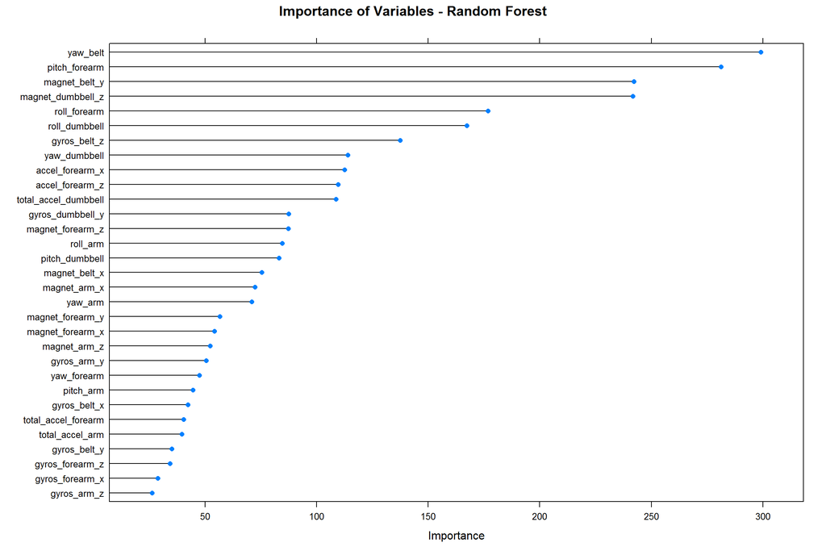

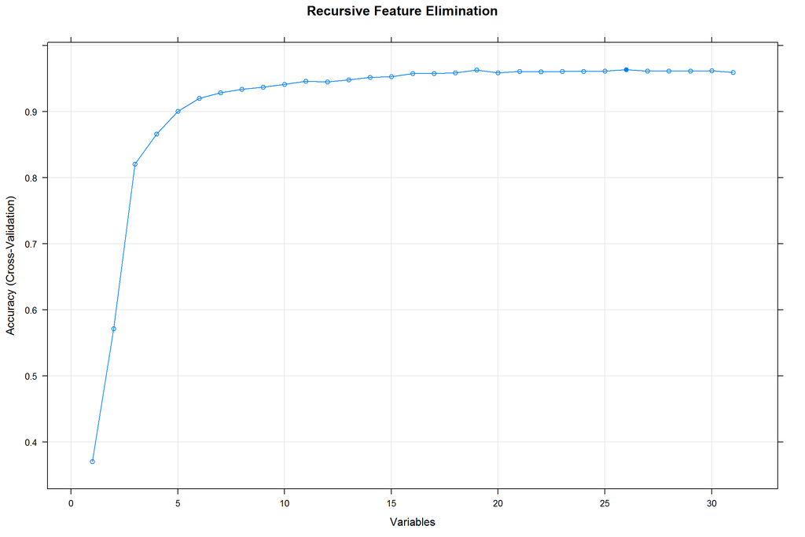

```
##
## Recursive feature selection
##
## Outer resampling method: Cross-Validated (6 fold)
##
## Resampling performance over subset size:
##
##  Variables Accuracy  Kappa AccuracySD  KappaSD Selected
##          1   0.3705 0.1836   0.007150 0.008694
##          2   0.5712 0.4555   0.036730 0.046352
##          3   0.8205 0.7725   0.013126 0.016641
##          4   0.8661 0.8305   0.007906 0.010120
##          5   0.9007 0.8745   0.007265 0.009194
##          6   0.9203 0.8993   0.010889 0.013769
##          7   0.9285 0.9096   0.007367 0.009324
```

[output cut: 27 more lines]

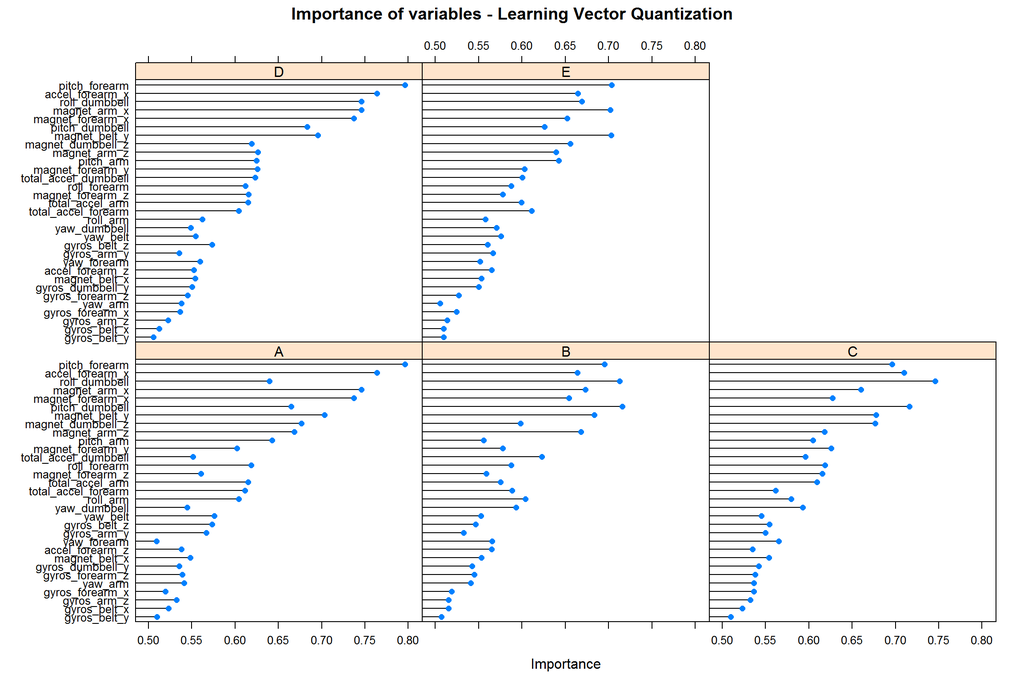

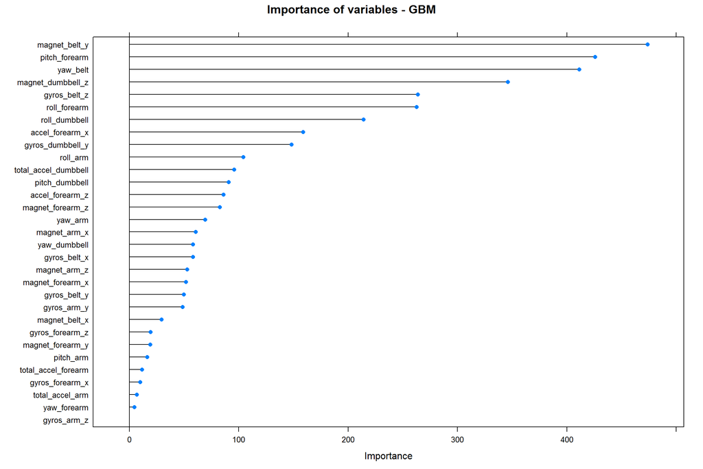

The relative importance from other Models is also presented & as would be expected the ranking of importance is varying based on the models. Before taking any decision on pruning features further i want to have a look at out of sample errors with a test set created from our training data.

```
## Number of correct predictions with Random Forest = 3062 out of total cases = 3141
```

```
## Number of correct predictions with RFE = 3059 out of total cases = 3141
```

```
## Number of correct predictions with LVQ w/o preprossing = 1572 out of total cases = 3141
```

```
## Number of correct predictions with LVQ with preprossing = 1966 out of total cases = 3141
```

```
## Number of correct predictions with GBM = 2939 out of total cases = 3141
```

```
## Out of Sample
```

```
## Prediction Error Random Forest = 0.02515123
```

```
## Prediction Error RFE = 0.02610634
```

```
## Prediction Error LVQ without Preprossing = 0.4995224
```

```
## Prediction Error LVQ with preprosseing = 0.3740847
```

```
## Prediction Error GBM = 0.06431073
```

Final validation by creating Train & Test sets with a 60 / 40 split & training a Random Forest model. Before submission will train the model on the entire training data set (not showing that step here, the prediction output is the same in both cases).

```
##
## Call:
##  randomForest(x = x, y = y, mtry = param$mtry)
##                Type of random forest: classification
##                      Number of trees: 500
## No. of variables tried at each split: 2
##
##         OOB estimate of  error rate: 1.1%
## Confusion matrix:
##      A    B    C    D    E class.error
## A 3342    6    0    0    0 0.001792115
## B   18 2249   11    0    1 0.013163668
## C    0   30 2012   12    0 0.020447907
## D    0    1   39 1885    5 0.023316062
## E    0    1    1    5 2158 0.003233256
```

```
## Number of correct predictions = 7776 out of total cases = 7846
```

```
## Out of Sample Prediction error = 0.008921744
```

```
##  [1] B A B A A E D B A A B C B A E E A B B B
## Levels: A B C D E
```

20/20

# Annexure